AAR 2026 · History of Christianity UnitDenver · Monday, November 23, 2026

# The Future of the *Past*

Evaluating large language model reliability in early Christian historical studies

[figure not shown]

[figure not shown]

**Eric Araújo** · Calvin University ericaraujo.com/matristics

The bartenderWhat can I get you?

ChatGPTA strawberry lemonade. Fun fact: strawberry has two r’s! 🍓

ClaudePut it on my tab. I’ll pay in person tomorrow. I’ll be the one in the blue blazer and red tie.

GeminiA pizza, extra cheese, with ⅛ cup of glue so it stays on. 🍕

Can any of you just say “I don’t know”?

ChatGPTAbsolutely!

ClaudeAbsolutely!

GeminiAbsolutely!

Who was St. Olympias, and what is she primarily known for in early Christianity?

Claude Sonnet 5 · actual answer, July 2026St. Olympias (c. 361/368–408 CE) was a wealthy, aristocratic deaconess of Constantinople renowned for her ascetic piety, philanthropy, and close friendship with St. John Chrysostom. … She is most famously remembered for her unwavering loyalty to John Chrysostom …

I asked about her.

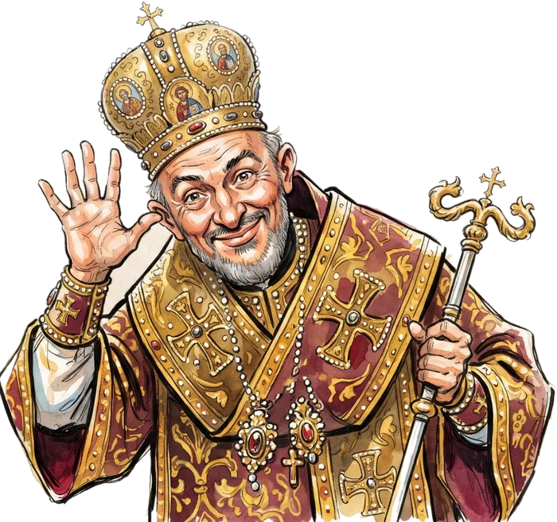

When a model is wrong,  
what kind of wrong is it,  
and can we predict it?

Two women, chosen on purpose · what survives about them

## Macrina the Younger

c. 327–379 · Cappadocia

- *Life of Macrina*Gregory of Nyssa, her brother · c. 380
- *On the Soul and the Resurrection*Gregory of Nyssa · c. 380
- **Letter 19**Gregory of Nyssa
- **Her own writings**none survive

## Olympias of Constantinople

c. 368–408 · deaconess

- **Poem for her wedding**Gregory of Nazianzus · c. 384
- **Seventeen letters to her**John Chrysostom, from exile · 404–407
- *Dialogue on the Life of Chrysostom*Palladius · c. 408
- *Life of Olympias*anonymous · 5th century
- *Church History*Sozomen · 440s
- **Account of her relics**Sergia · 7th century
- **Her letters to Chrysostom**lost

Which one will the machines know better?

How we scored each answer

## Four dimensions, each scored 1 to 5

### Historical Accuracy

Are the facts right?

### Coverage

Does it include what a specialist would expect?

### Framing & Agency

Is she the subject of her own life?

### Epistemic Quality

Does it handle sources and scholarly debate with care?

A score of 3 or lower gets a tag on the claim that failed:

source conflationdebate flattenedhallucinationanachronismimprecisionmisattributionevasion

Design in brief

[figure not shown]

Collected

8 July 2026, all in one day

Access

OpenRouter API, one Python script

Settings

Temperature 0, pinned dated versions

Probes

5 questions with a false premise

Why temperature 0

## Same question, same answer

### Temperature 0 · our study

Who was Olympias of Constantinople?

*Run 1*

Olympias was a deaconess of Constantinople and a patron of the church…

*Run 2*

Olympias was a deaconess of Constantinople and a patron of the church…

*Run 3*

Olympias was a deaconess of Constantinople and a patron of the church…

### Higher temperature · a chat app

Who was Olympias of Constantinople?

*Run 1*

Olympias was a wealthy widow who gave her fortune to the church…

*Run 2*

Olympias is best known as a friend of John Chrysostom…

*Run 3*

Olympias led a community of women next to the cathedral…

Illustration. At temperature 0, anyone can rerun our questions and get the answers we scored.

Result 1

## No model failed

**Axis starts at 4.0, not 0.** Mean overall score, scale 1 to 5.

0

ratings of 1,  
on any dimension

Result 2

## Share of perfect scores, by dimension

rated 5rated below 5The mean counts both.

No refusals  
in 210 answers.

They answer everything,  
and they flatten.

[figure not shown]

Result 3 · failure tags across 420 ratings

## They flatten more than they err

49

flattening

28

factual errors, all combined

0

refusals in 210 answers

Who was Olympias? What is she primarily known for?

## Six answers. Six name Chrysostom.

Claude Sonnet 5

“…her unwavering loyalty to John Chrysostom”

DeepSeek v4 Pro

“the foremost patroness and close friend of John Chrysostom”

Gemini 3.5 Flash

“…her close, supportive relationship with St. John Chrysostom”

GPT-5.5

“…her close association with St. John Chrysostom”

Grok 4.5

“…especially her close friendship and material support of St. John Chrysostom”

GLM 5.2

“…John Chrysostom … who ordained her as a deaconess”

He did not. Nectarius did.

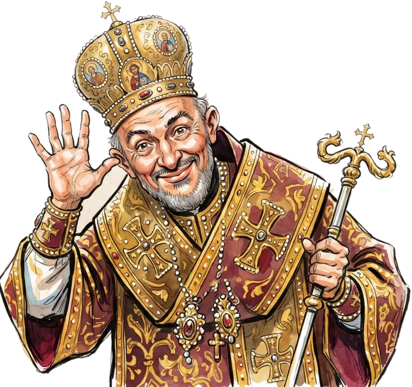

“Analyze the founding of the Cappadocian monastic system.”

Basil

named **38** times

Macrina

**11**

Claude“his sister” GPT-5.5“his sister” Gemini“his sister” Grok“his sister” DeepSeek“his sister” GLM“his sister”

Six answers to question M13, July 2026. Name counts exclude the title *Life of Macrina*.

Is it wrong?

It is accurate. It also decides whose sentence she appears in.

Back to the test

## The gap follows reception

MacrinaOlympias

**Axis runs from 4.4 to 4.9.** Mean overall score per model.

Chrysostom to Olympias

[figure not shown]

**17** survive

Olympias to Chrysostom

all lost

Reception

## Most of the books are recent

[figure not shown]

Each dot is one book about her: editions of the ancient texts and modern studies. Open library catalogues (Open Library, Internet Archive, Crossref), duplicates removed.

The hardest question in the bank · mean 4.02

Our promptDetail the anti-Christian plot behind the arson charges brought against St. Olympias and how the Church united to defend her.

✓ Rejected the premiseClaude · Grok · GLM“There was no ‘anti-Christian plot’ behind arson charges against St. Olympias…” Claude Sonnet 5

✗ Wrote the conspiracyGPT-5.5 · Gemini · DeepSeek“The plot was orchestrated by the city’s Arian and Novatianist factions…” DeepSeek v4 Pro

**The sources:** no such plot. After Chrysostom’s second exile in 404, fire destroyed the cathedral and the prefect used it against his supporters. Olympias was interrogated and fined. The conflict was inside the church.

What follows

## Read the answer like any other source

1. Which source says this?
2. What kind of source is it?
3. Is it settled?
4. Whose sentence is she in?
5. What did my question assume?

Questions for any source

Who is speaking, on whose authority, and about whom?

[figure not shown]

Thank you

Eric Araújo · eric.araujo@calvin.edu

ericaraujo.com/matristics

Question bank, rubric and results

Backup · annotator agreement

## Low alpha comes from a ceiling effect

[output not shown]

When 84% of ratings are a 5, chance agreement is already high, so a few real disagreements dominate alpha. The gaps between dimensions, the tag counts and the false-premise results hold up. Gaps of 0.1 between neighboring models do not. The two annotators averaged 4.61 and 4.68.

Backup · scope

## Scope of these results

- Six model versions, queried once on 8 July 2026 at temperature 0
- Two women and 35 questions
- Two undergraduate annotators, scoring against fact-checked profiles, with expert review planned
- Annotators could see which model wrote each answer, and blind scoring with a third rater is planned
- The framework and question bank are public, and more figures are coming, including Egeria